# Basic Analyses of Isotopic Variation

Andrew L Jackson & Chris Harrod

26 March, 2025

```r
library(tidyverse)
```

In this practical, we will explore our data in more detail using some basic statistical tests to identify where the variation in our data lies, and hence where the interesting ecological insights might lie. In this example dataset, we have d13C, d15N and C:N ratio from three fish species.

```r
mydata <- read.csv("Practical02.csv", header = TRUE, stringsAsFactors = FALSE)

# force species to be a factor type variable
mydata$Species <- factor(mydata$Species)

# verify that it imported as expected
head(mydata)
```

|  | Species | Length | Muscle.d13C | Muscle.d15N | Muscle.CN | Liver.d13C | Liver.d15N | Liver.CN |
| --- | --- | --- | --- | --- | --- | --- | --- | --- |
| 1 | Arrowtooth.Flounder | 320 | -19.05163 | 15.32761 | 3.207627 | -22.46728 | 15.13437 | 6.957752 |
| 2 | Arrowtooth.Flounder | 170 | -19.32353 | 13.27570 | 3.208622 | -21.37746 | 13.00691 | 7.501159 |
| 3 | Arrowtooth.Flounder | 180 | -19.32724 | 12.81221 | 3.132603 | -22.24820 | 13.19996 | 8.645249 |
| 4 | Arrowtooth.Flounder | 360 | -18.48075 | 15.26385 | 3.233318 | -20.12995 | 14.49240 | 4.434565 |
| 5 | Arrowtooth.Flounder | 160 | -19.46689 | 12.98392 | 3.265972 | -22.64738 | 12.32679 | 9.137755 |
| 6 | Arrowtooth.Flounder | 500 | -19.57439 | 15.59422 | 3.657918 | -23.03638 | 15.27908 | 13.861959 |

```r
NA
```

## Summarise by Species

```r
mydata %>% group_by(Species) %>%
  summarise(count = n(),
            mean_length = mean(Length),
            mean_muscle_d13C = mean(Muscle.d13C),
            mean_muscle_d15N = mean(Muscle.d15N),
            mean_liver_d13C = mean(Liver.d13C),
            mean_liver_d15N = mean(Liver.d15N))
```

| Species | count | mean_length | mean_muscle_d13C | mean_muscle_d15N | mean_liver_d13C | mean_liver_d15N |
| --- | --- | --- | --- | --- | --- | --- |
| Arrowtooth.Flounder | 29 | 328.9655 | -20.07823 | 14.64197 | -22.16325 | 14.20671 |
| Pacific.cod | 39 | 488.9744 | -18.07187 | 17.98490 | -21.78326 | 16.77087 |
| Pollock | 45 | 494.2222 | -19.23248 | 15.60045 | -23.64189 | 14.05758 |

```r
NA
NA
NA
```

## Lipid correction

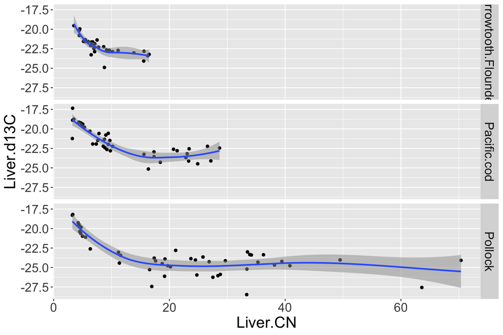

```r
# code to do this using base R graphics
# plot(Liver.d13C ~ Liver.CN, data = mydata,
#      subset = Species == "Arrowtooth.Flounder", main = "Arrowtooth.Flounder")
#
# # lowess smoother not working like this for the subset.
# # lines(lowess(mydata$Liver.CN, mydata$Liver.d13C), col = "red")
#
# plot(Liver.d13C ~ Liver.CN, data = mydata,
#      subset = Species == "Pacific.cod", main = "Pacific.cod")
#
# plot(Liver.d13C ~ Liver.CN, data = mydata,
#      subset = Species == "Pollock", main = "Pollock")

# try to do this in ggplot using facets
library(tidyverse)
liver.plot <- ggplot(data = mydata,
                     mapping = aes(x = Liver.CN,
                                   y = Liver.d13C)) +
  geom_point() +
  geom_smooth(method = "loess", alpha = 0.5) +
  facet_grid(Species~.) +
  theme(text = element_text(size=20))
print(liver.plot)
```

The liver in particular has a large quantity of lipids, and in this example, we apply a simple numerical correction based on [Logan et al 2008](https://doi.org/10.1111/j.1365-2656.2008.01394.x). This correction is weighted by the C/N ratio, such that high amounts of C require a greater correction.

See also [Post et al 2007](https://doi.org/10.1007/s00442-006-0630-x) for a good review of lipid correction.

This review by [Kiljunen et al 2006](https://besjournals.onlinelibrary.wiley.com/doi/full/10.1111/j.1365-2664.2006.01224.x) offers some suggestions too.

```r
# constants used in the correction for liver tissue
a <-   6.059
b <- -22.270
c <-  -1.397

# add columns for lipid corrected liver to the data.frame
mydata <- mydata %>%
  mutate(Liver.d13C.crtd = Liver.d13C +
           (a * Liver.CN + b) / (Liver.CN + c))

# mydata$Liver.d13C.crtd <-  mydata$Liver.d13C +
#   (a * mydata$Liver.CN + b) / (mydata$Liver.CN + c)

# check that it worked as expected
head(mydata)
```

|  | Species | Length | Muscle.d13C | Muscle.d15N | Muscle.CN | Liver.d13C | Liver.d15N | Liver.CN | Liver.d13C.crtd |
| --- | --- | --- | --- | --- | --- | --- | --- | --- | --- |
| 1 | Arrowtooth.Flounder | 320 | -19.05163 | 15.32761 | 3.207627 | -22.46728 | 15.13437 | 6.957752 | -18.89096 |
| 2 | Arrowtooth.Flounder | 170 | -19.32353 | 13.27570 | 3.208622 | -21.37746 | 13.00691 | 7.501159 | -17.58013 |
| 3 | Arrowtooth.Flounder | 180 | -19.32724 | 12.81221 | 3.132603 | -22.24820 | 13.19996 | 8.645249 | -18.09388 |
| 4 | Arrowtooth.Flounder | 360 | -18.48075 | 15.26385 | 3.233318 | -20.12995 | 14.49240 | 4.434565 | -18.61590 |
| 5 | Arrowtooth.Flounder | 160 | -19.46689 | 12.98392 | 3.265972 | -22.64738 | 12.32679 | 9.137755 | -18.37187 |
| 6 | Arrowtooth.Flounder | 500 | -19.57439 | 15.59422 | 3.657918 | -23.03638 | 15.27908 | 13.861959 | -18.08493 |

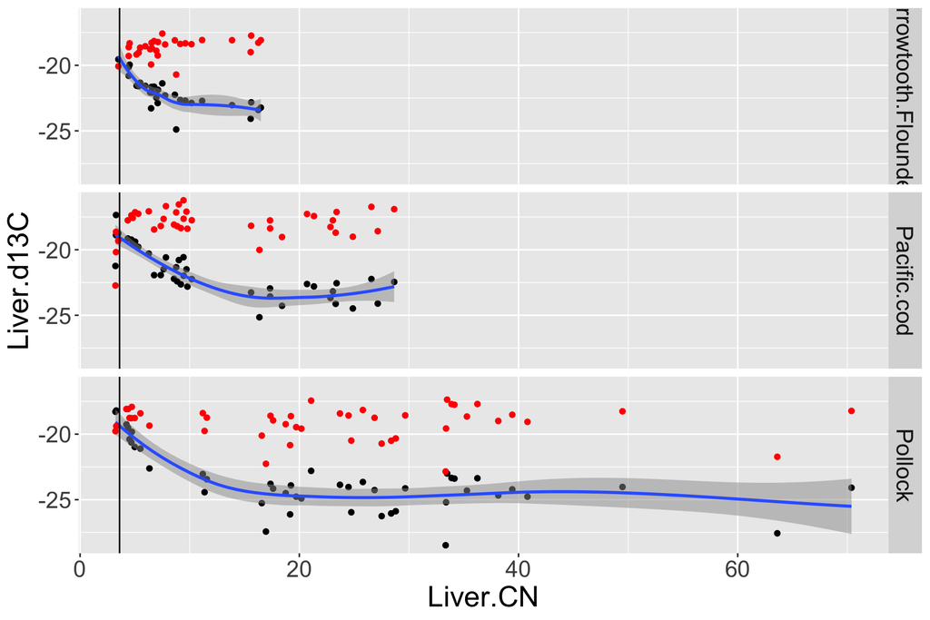

```r
# specify a color pallete with 3 colours for this example
# palette(c("black", "red", "blue"))

# plot the correlation between the corrected and raw values, and
# indicate which observations have large C/N ratios by the
# size of the datapoints.
# plot(Liver.d13C.crtd ~ Liver.d13C, data = mydata,
#      col = Species, cex = 5 * Liver.CN / max(Liver.CN), pch = 19, asp = 1)
#
# # add the 1:1 line
# abline(a = 0, b = 1, col = "grey", lty = 1, lwd = 2)
#
#
# # reset the colour palette to the default
# palette("default")

# now plot the corrected values on top of our raw data from before
# and add a vertical line at 3.6 which is "pure protein"
liver.plot.2 <- liver.plot +
  geom_point(data = mydata, aes(x = Liver.CN,
                                y = Liver.d13C.crtd),
             col = "red") +
  geom_vline(xintercept = 3.6, col = "black")

print(liver.plot.2)
```

```r
ggsave(plot = liver.plot.2,
       filename = "../../images/lipid_corrected_liver.jpg")
```

## Basic summary statistics

As always, it is sensible to start by taking a quick look at the summary statistics describing the data, and how the data are encoded in R. The only bit of code I’ve changed here is to make the text of the correlation coefficient text a bit smaller when defining the function `panel.cor()`.

```r
# how are the data encoded in R?
str(mydata)
```

```
'data.frame':   113 obs. of  9 variables:
 $ Species        : Factor w/ 3 levels "Arrowtooth.Flounder",..: 1 1 1 1 1 1 1 1 1 1 ...
 $ Length         : int  320 170 180 360 160 500 420 350 370 480 ...
 $ Muscle.d13C    : num  -19.1 -19.3 -19.3 -18.5 -19.5 ...
 $ Muscle.d15N    : num  15.3 13.3 12.8 15.3 13 ...
 $ Muscle.CN      : num  3.21 3.21 3.13 3.23 3.27 ...
 $ Liver.d13C     : num  -22.5 -21.4 -22.2 -20.1 -22.6 ...
 $ Liver.d15N     : num  15.1 13 13.2 14.5 12.3 ...
 $ Liver.CN       : num  6.96 7.5 8.65 4.43 9.14 ...
 $ Liver.d13C.crtd: num  -18.9 -17.6 -18.1 -18.6 -18.4 ...
```

```r
# a basic summary of each column in the data.frame
summary(mydata)
```

```
                Species       Length     Muscle.d13C      Muscle.d15N      Muscle.CN
 Arrowtooth.Flounder:29   Min.   : 90   Min.   :-23.41   Min.   :12.49   Min.   : 3.105
 Pacific.cod        :39   1st Qu.:270   1st Qu.:-19.75   1st Qu.:14.57   1st Qu.: 3.184
 Pollock            :45   Median :480   Median :-18.83   Median :16.03   Median : 3.235
                          Mean   :450   Mean   :-19.05   Mean   :16.18   Mean   : 3.901
                          3rd Qu.:620   3rd Qu.:-18.11   3rd Qu.:17.79   3rd Qu.: 3.327
                          Max.   :820   Max.   :-16.77   Max.   :20.10   Max.   :21.149
   Liver.d13C       Liver.d15N        Liver.CN      Liver.d13C.crtd
 Min.   :-28.48   Min.   : 9.896   Min.   : 3.225   Min.   :-22.85
 1st Qu.:-24.08   1st Qu.:13.336   1st Qu.: 6.395   1st Qu.:-19.03
 Median :-22.71   Median :15.125   Median :10.189   Median :-18.41
 Mean   :-22.62   Mean   :15.032   Mean   :15.793   Mean   :-18.62
 3rd Qu.:-21.38   3rd Qu.:16.750   3rd Qu.:23.063   3rd Qu.:-17.92
 Max.   :-17.35   Max.   :20.273   Max.   :70.376   Max.   :-16.23
```

```r
# how many obverations do we have per Taxon might also be of use
table(mydata$Species)
```

```
Arrowtooth.Flounder         Pacific.cod             Pollock
                 29                  39                  45
```

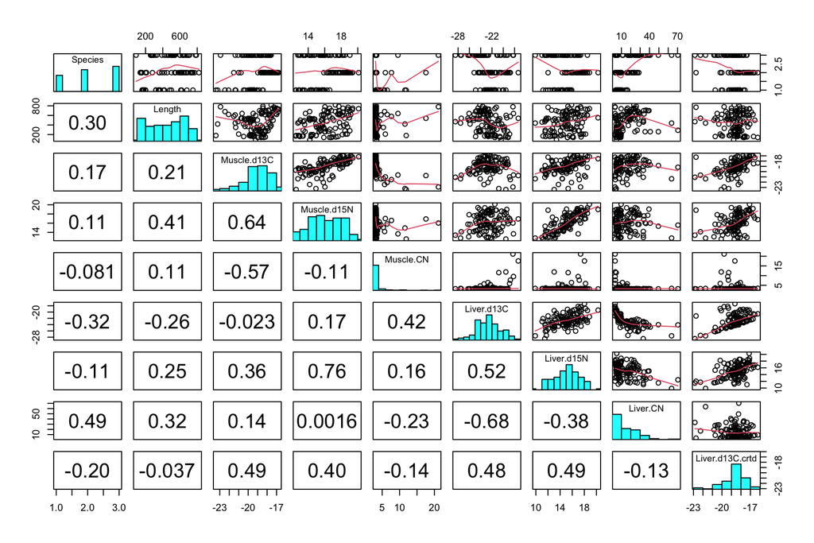

```r
# Using datq from our first practical, generate all pair-wise scatterplots
# = = = = = = = = = = = = = = = = = = = = = = = = = = = = = =
# source("my_functions.R")
# These functions are copied from the help file for pairs()
## put histograms on the diagonal
panel.hist <- function(x, ...)
{
    usr <- par("usr"); on.exit(par(usr))
    par(usr = c(usr[1:2], 0, 1.5) )
    h <- hist(x, plot = FALSE)
    breaks <- h$breaks; nB <- length(breaks)
    y <- h$counts; y <- y/max(y)
    rect(breaks[-nB], 0, breaks[-1], y, col = "cyan", ...)
}

panel.cor <- function(x, y, digits = 2, prefix = "", cex.cor, ...)
{
    usr <- par("usr"); on.exit(par(usr))
    par(usr = c(0, 1, 0, 1))
    r <- cor(x, y)
    txt <- format(c(r, 0.123456789), digits = digits)[1]
    txt <- paste0(prefix, txt)
    if(missing(cex.cor)) cex.cor <- 0.4/strwidth(txt)
    # text(0.5, 0.5, txt, cex = cex.cor * r)
    text(0.5, 0.5, txt, cex = 2)
}

# = = = = = = = = = = = = = = = = = = = = = = = = = = = = = =

# this select function comes from the package dplyr and allows us to
# select a subset of columns to plot.
pairs(mydata,
      diag.panel = panel.hist,
      upper.panel = panel.smooth,
      lower.panel = panel.cor)
```

```r
NA
NA
NA
```

## Focus on variation among species

Using code from the first practical, we can use the package `dplyr` to generate summary statistics on the means and variation of each species in the dataset. I summarise the muscle and liver (using the lipid-corrected d13C) data separately only to keep the resulting table smaller and nicer to print.

```r
# Summarise the data by group using the package dplyr (install if required)

# load the library
library(tidyverse)

summarise.muscle <- mydata %>% group_by(Species) %>%
  summarise(count = length(Species),
            musC = mean(Muscle.d13C), musSdC =  sd(Muscle.d13C),
            musN = mean(Muscle.d15N), musSdN =  sd(Muscle.d15N),
            musCN = mean(Muscle.CN),  musSdCN = sd(Muscle.CN))

# print a pretty table
knitr::kable(summarise.muscle, digits = 2)
```

| Species | count | musC | musSdC | musN | musSdN | musCN | musSdCN |
| --- | --- | --- | --- | --- | --- | --- | --- |
| Arrowtooth.Flounder | 29 | -20.08 | 1.30 | 14.64 | 1.2 | 4.30 | 2.21 |
| Pacific.cod | 39 | -18.07 | 1.07 | 17.98 | 1.0 | 3.78 | 2.41 |
| Pollock | 45 | -19.23 | 1.12 | 15.60 | 1.7 | 3.75 | 2.82 |

```r
# print(summarise.muscle)


summarise.liver <- mydata %>% group_by(Species) %>%
  summarise(count = length(Species),
            livC.c = mean(Liver.d13C.crtd),
            livSdC.c =  sd(Liver.d13C.crtd),
            livN = mean(Liver.d15N),
            livSdN =  sd(Liver.d15N),
            livCN = mean(Liver.CN),
            livSdCN = sd(Liver.CN) )

# print a pretty table
knitr::kable(summarise.liver, digits = 2)
```

| Species | count | livC.c | livSdC.c | livN | livSdN | livCN | livSdCN |
| --- | --- | --- | --- | --- | --- | --- | --- |
| Arrowtooth.Flounder | 29 | -18.66 | 0.70 | 14.21 | 1.34 | 8.38 | 3.79 |
| Pacific.cod | 39 | -18.02 | 1.18 | 16.77 | 1.48 | 12.65 | 7.97 |
| Pollock | 45 | -19.12 | 1.22 | 14.06 | 1.97 | 23.29 | 15.43 |

```r
# print(summarise.liver)
```

The most suitable way to visualise the variation in the key tissues by species is probably to use simple boxplots. From here on in we will probably focus on the muscle data only and will put analysis of the liver samples on hold.

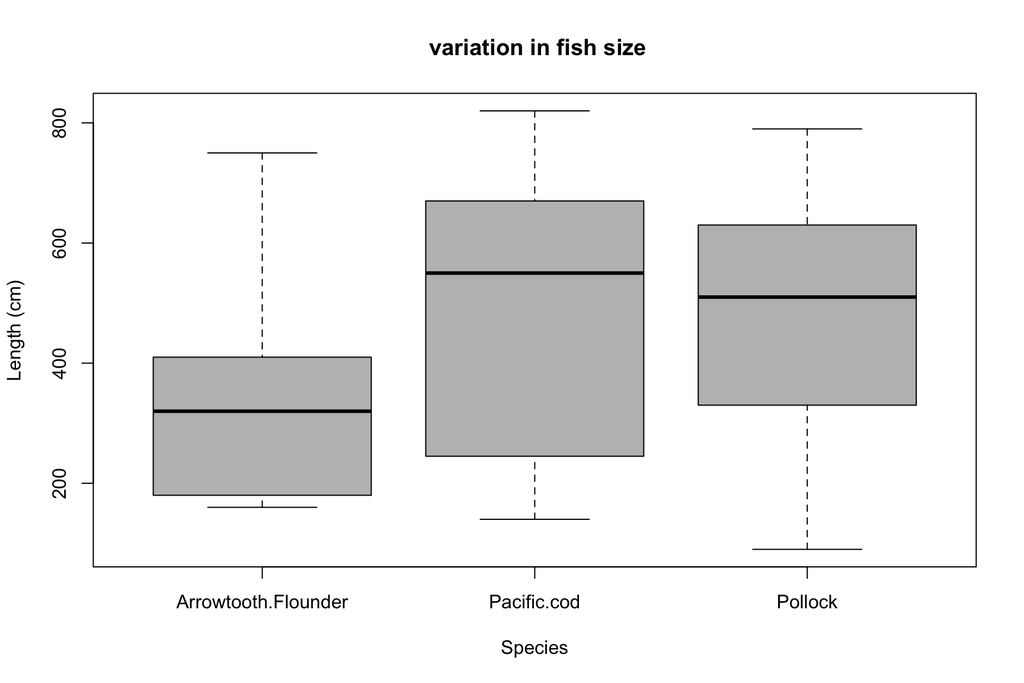

```r
boxplot(Length ~ Species, data = mydata, col="grey",
        xlab="Species", ylab="Length (cm)",
        main = " variation in fish size")
```

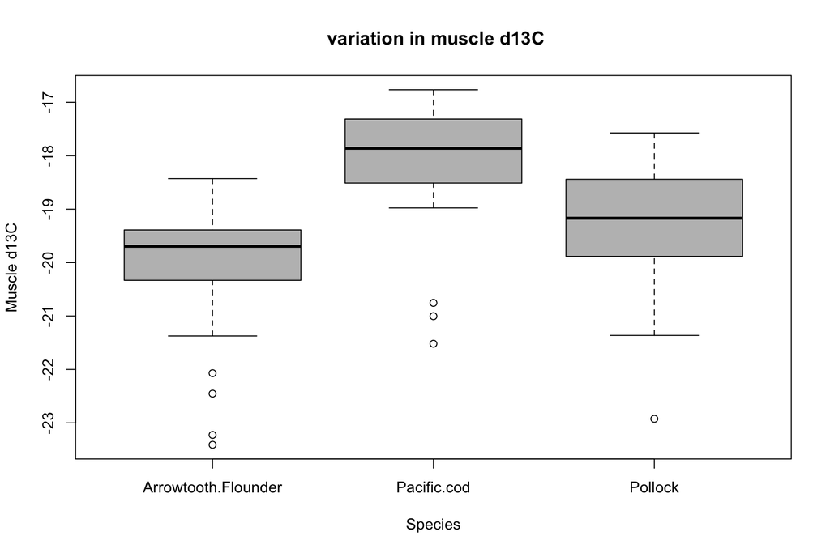

```r
boxplot(Muscle.d13C ~ Species, data = mydata, col="grey",
        xlab="Species", ylab="Muscle d13C",
        main = " variation in muscle d13C")
```

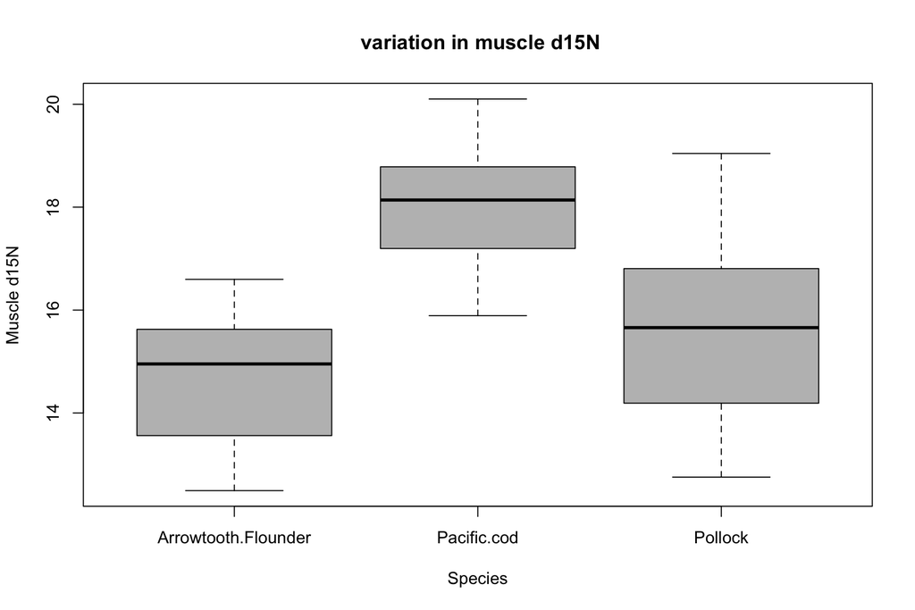

```r
#now d15N
boxplot(Muscle.d15N ~ Species, data = mydata, col="grey",
        xlab="Species", ylab="Muscle d15N",
        main = " variation in muscle d15N")
```

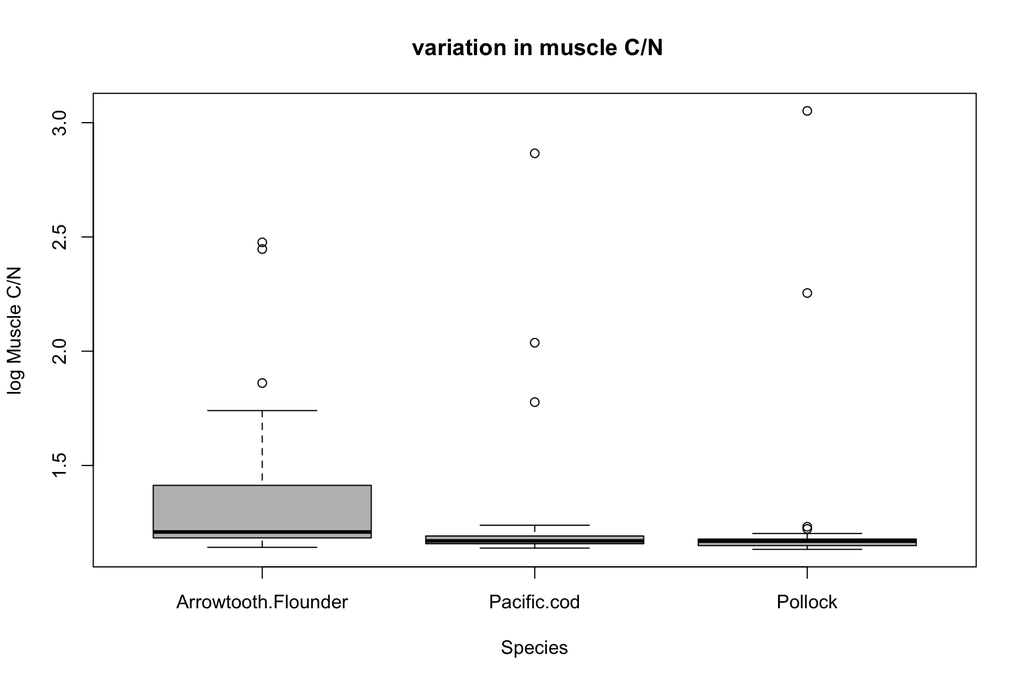

```r
#now d15N
boxplot(log(Muscle.CN) ~ Species, data = mydata, col="grey",
        xlab="Species", ylab="log Muscle C/N",
        main = " variation in muscle C/N")
```

```r
NA
NA
```

An appropriate statistical test to determine whether the means of these boxplots are significantly different from one another is a simple ANOVA. You need to take a little care here, as the function you want when analysing data is called `aov()` in R (for Analysis of Variance) whereas there is also a function `anova()` but it is used to compare fitted linear model objects (a discussion point for another day, and one i wouldnt recommend in any case). I have log-transformed the C/N data owing to the heavy skew evident in the pairs plot above.

```r
# length by species
length.aov <-  aov(Length ~ Species, data = mydata)
summary(length.aov)
```

```
             Df  Sum Sq Mean Sq F value   Pr(>F)
Species       2  572074  286037   7.872 0.000638 ***
Residuals   110 3996926   36336
---
Signif. codes:  0 ‘***’ 0.001 ‘**’ 0.01 ‘*’ 0.05 ‘.’ 0.1 ‘ ’ 1
```

```r
# muscle carbon by species
muscleC.aov <- aov(Muscle.d13C ~ Species, data = mydata)
summary(muscleC.aov)
```

```
             Df Sum Sq Mean Sq F value   Pr(>F)
Species       2  69.47   34.74   26.07 5.41e-10 ***
Residuals   110 146.57    1.33
---
Signif. codes:  0 ‘***’ 0.001 ‘**’ 0.01 ‘*’ 0.05 ‘.’ 0.1 ‘ ’ 1
```

```r
# muscle N by species
muscleN.aov <- aov(Muscle.d15N ~ Species, data = mydata)
summary(muscleN.aov)
```

```
             Df Sum Sq Mean Sq F value Pr(>F)
Species       2  210.8  105.38   56.49 <2e-16 ***
Residuals   110  205.2    1.87
---
Signif. codes:  0 ‘***’ 0.001 ‘**’ 0.01 ‘*’ 0.05 ‘.’ 0.1 ‘ ’ 1
```

```r
# muscle C/N ratio by species
muscleCN.aov <- aov(log(Muscle.CN) ~ Species, data = mydata)
summary(muscleCN.aov)
```

```
             Df Sum Sq Mean Sq F value Pr(>F)
Species       2  0.437  0.2184   2.044  0.134
Residuals   110 11.757  0.1069
```

Identifying which species are different from each other can be acheived using post-hoc tests that correct the p-values to take account of the multiple testing involved. Just looking at the d13C muscle data in this example (you can try the others as you like):

```r
TukeyHSD(muscleC.aov)
```

```
  Tukey multiple comparisons of means
    95% family-wise confidence level

Fit: aov(formula = Muscle.d13C ~ Species, data = mydata)

$Species
                                      diff        lwr        upr     p adj
Pacific.cod-Arrowtooth.Flounder  2.0063584  1.3338843  2.6788325 0.0000000
Pollock-Arrowtooth.Flounder      0.8457546  0.1926797  1.4988296 0.0073897
Pollock-Pacific.cod             -1.1606038 -1.7606068 -0.5606007 0.0000343
```

## Is it length or species that drives variation in d13C and d15N?

We might focus on d13C first.

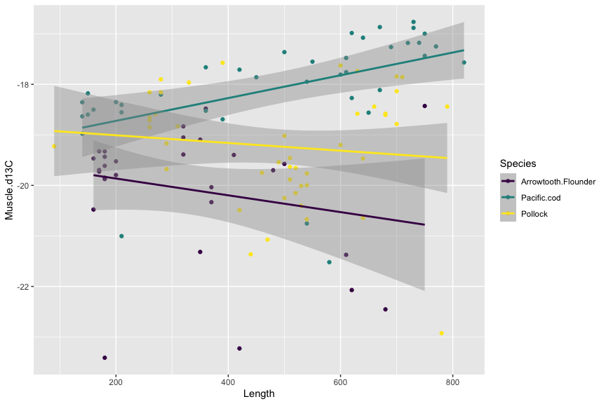

```r
g_muscle_C <- ggplot(data = mydata,
                     mapping = aes(x = Length,
                                   y = Muscle.d13C,
                                   color = Species)) +
  geom_point() +
  geom_smooth(method = "lm") +
  scale_color_viridis_d(end = 1)

print(g_muscle_C)
```

```r
d13C.length.model <- glm(Muscle.d13C ~ Species + Length, data = mydata)
summary(d13C.length.model)
```

```
Call:
glm(formula = Muscle.d13C ~ Species + Length, data = mydata)

Coefficients:
                     Estimate Std. Error t value Pr(>|t|)
(Intercept)        -2.024e+01  2.867e-01 -70.593  < 2e-16 ***
SpeciesPacific.cod  1.927e+00  2.981e-01   6.464 2.96e-09 ***
SpeciesPollock      7.635e-01  2.913e-01   2.621    0.010 *
Length              4.975e-04  5.781e-04   0.861    0.391
---
Signif. codes:  0 ‘***’ 0.001 ‘**’ 0.01 ‘*’ 0.05 ‘.’ 0.1 ‘ ’ 1

(Dispersion parameter for gaussian family taken to be 1.335639)

    Null deviance: 216.05  on 112  degrees of freedom
Residual deviance: 145.58  on 109  degrees of freedom
AIC: 359.31

Number of Fisher Scoring iterations: 2
```

```r
d13C.interaction.model <- glm(Muscle.d13C ~ Species + Length + Species:Length,
                              data = mydata)
summary(d13C.interaction.model)
```

```
Call:
glm(formula = Muscle.d13C ~ Species + Length + Species:Length,
    data = mydata)

Coefficients:
                            Estimate Std. Error t value Pr(>|t|)
(Intercept)               -1.953e+01  4.528e-01 -43.137  < 2e-16 ***
SpeciesPacific.cod         3.581e-01  6.268e-01   0.571  0.56901
SpeciesPollock             6.764e-01  6.919e-01   0.978  0.33048
Length                    -1.661e-03  1.223e-03  -1.358  0.17740
SpeciesPacific.cod:Length  3.914e-03  1.466e-03   2.671  0.00875 **
SpeciesPollock:Length      8.981e-04  1.582e-03   0.568  0.57144
---
Signif. codes:  0 ‘***’ 0.001 ‘**’ 0.01 ‘*’ 0.05 ‘.’ 0.1 ‘ ’ 1

(Dispersion parameter for gaussian family taken to be 1.25048)

    Null deviance: 216.05  on 112  degrees of freedom
Residual deviance: 133.80  on 107  degrees of freedom
AIC: 353.77

Number of Fisher Scoring iterations: 2
```

And now we could consider d15N in a similar manner.

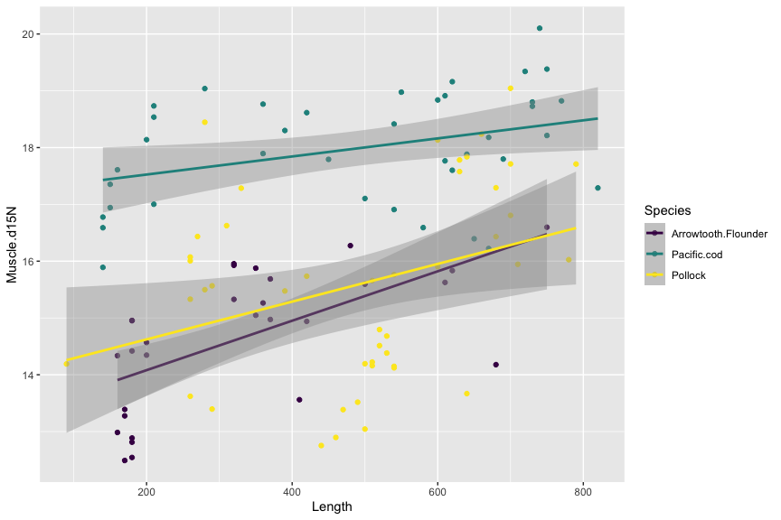

```r
g_muscle_N <- ggplot(data = mydata,
                     mapping = aes(x = Length,
                                   y = Muscle.d15N,
                                   color = Species)) +
  geom_point() +
  geom_smooth(method = "lm") +
  scale_color_viridis_d(end = 1)

print(g_muscle_N)
```

```r
d15N.length.model <- glm(Muscle.d15N ~ Species + Length, data = mydata)
summary(d15N.length.model)
```

```
Call:
glm(formula = Muscle.d15N ~ Species + Length, data = mydata)

Coefficients:
                    Estimate Std. Error t value Pr(>|t|)
(Intercept)        1.375e+01  3.152e-01  43.629  < 2e-16 ***
SpeciesPacific.cod 2.910e+00  3.277e-01   8.880 1.52e-14 ***
SpeciesPollock     5.111e-01  3.202e-01   1.596    0.113
Length             2.707e-03  6.354e-04   4.260 4.35e-05 ***
---
Signif. codes:  0 ‘***’ 0.001 ‘**’ 0.01 ‘*’ 0.05 ‘.’ 0.1 ‘ ’ 1

(Dispersion parameter for gaussian family taken to be 1.613847)

    Null deviance: 415.96  on 112  degrees of freedom
Residual deviance: 175.91  on 109  degrees of freedom
AIC: 380.69

Number of Fisher Scoring iterations: 2
```

```r
d15N.interaction.model <- glm(Muscle.d15N ~ Species + Length + Species:Length,
                              data = mydata)
summary(d15N.interaction.model)
```

```
Call:
glm(formula = Muscle.d15N ~ Species + Length + Species:Length,
    data = mydata)

Coefficients:
                           Estimate Std. Error t value Pr(>|t|)
(Intercept)               13.210039   0.511550  25.824  < 2e-16 ***
SpeciesPacific.cod         3.996839   0.708167   5.644 1.38e-07 ***
SpeciesPollock             0.747900   0.781648   0.957  0.34081
Length                     0.004353   0.001382   3.150  0.00212 **
SpeciesPacific.cod:Length -0.002762   0.001656  -1.668  0.09824 .
SpeciesPollock:Length     -0.001029   0.001787  -0.576  0.56585
---
Signif. codes:  0 ‘***’ 0.001 ‘**’ 0.01 ‘*’ 0.05 ‘.’ 0.1 ‘ ’ 1

(Dispersion parameter for gaussian family taken to be 1.596111)

    Null deviance: 415.96  on 112  degrees of freedom
Residual deviance: 170.78  on 107  degrees of freedom
AIC: 381.35

Number of Fisher Scoring iterations: 2
```

While d15N appears to scale positively with length (**and you can probably think why this might be**), d13C does not appear to be affected by length. You could assess this by comparing a model without `length` using AIC, where we are looking for AIC to be lower by more than 2 units if we are to justify the inclusion of `length` in the model:

```r
d13C.species.model <- glm(Muscle.d13C ~ Species, data = mydata)
summary(d13C.species.model)
```

```
Call:
glm(formula = Muscle.d13C ~ Species, data = mydata)

Coefficients:
                   Estimate Std. Error t value Pr(>|t|)
(Intercept)        -20.0782     0.2144 -93.668  < 2e-16 ***
SpeciesPacific.cod   2.0064     0.2830   7.088 1.37e-10 ***
SpeciesPollock       0.8458     0.2749   3.077  0.00264 **
---
Signif. codes:  0 ‘***’ 0.001 ‘**’ 0.01 ‘*’ 0.05 ‘.’ 0.1 ‘ ’ 1

(Dispersion parameter for gaussian family taken to be 1.332492)

    Null deviance: 216.05  on 112  degrees of freedom
Residual deviance: 146.57  on 110  degrees of freedom
AIC: 358.08

Number of Fisher Scoring iterations: 2
```

Based on this comparison, with an AIC of 359.31 for the model with length, and an AIC of 358.08 without length, we can conclude that length does not add sufficient explanatory information to warrant its inclusion.

**Task:** You might want to check whether there is an interaction between species and length in this relationship. Essentially this involves fitting 3 lines, one for each species by length. You can add an interaction to the `glm()` formulae, using a `:` to specify which variables interact.

## Pair-wise comparisons of the different tissues

We might well ask whether the isotope values are the same between the liver and muscle tissues within the individual fish. To acheive this, we can conduct a pair-wise t-test that adds power over a standard t-test by treating the observations as being matched, or paired. Since we can’t use the formula method (`y~x`) easily when we have two columns (vectors) of data to compare, we can’t use the `data = mydata` option, and so we have to use the `$` notation to provide the two vectors for comparison. We can’t even use the `subset =` option so instead we have to subset each of our vectors manually: `mydata$Muscle.d13C[mydata$Species == "Arrowtooth.Flounder"]`.

You could take this code, copy it and modify it to run paired t-tests on the other species.

```r
t.test(mydata$Muscle.d13C[mydata$Species == "Arrowtooth.Flounder"],
       mydata$Liver.d13C.crtd[mydata$Species == "Arrowtooth.Flounder"],
       paired = TRUE)
```

```
    Paired t-test

data:  mydata$Muscle.d13C[mydata$Species == "Arrowtooth.Flounder"] and mydata$Liver.d13C.crtd[mydata$Species == "Arrowtooth.Flounder"]
t = -6.1193, df = 28, p-value = 1.328e-06
alternative hypothesis: true mean difference is not equal to 0
95 percent confidence interval:
 -1.8971660 -0.9455698
sample estimates:
mean difference
      -1.421368
```

## Use multivariate statistics to compare d13C and d15N simultaneously among species

Visualising the multivariate data is easiest if we add ellipses over each species group as we did in the first practical session. The code that follows is taken from there and modified accordingly to make sure the $x$ and $y$ data names are appropriate for this new dataset.

Now we can make a nice plot with `ggplot` taking care to change the aesthetics to make our column names if we just copied and pasted this in from the first practical file.

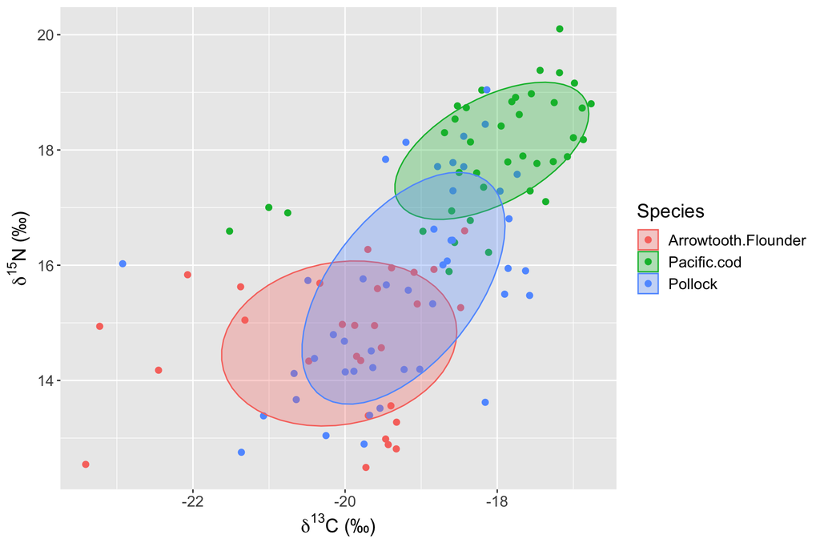

```r
# load the library
library(ggplot2)

# use our ellipse function to generate the ellipses for plotting

# this is the basic plot, which im not actually going to plot
# as i won't call print(first.plot). Doing this is purely choice,
# and for me it keeps my code tidier and easier to interpret
first.plot <- ggplot(data = mydata, aes(Muscle.d13C, Muscle.d15N)) +
  geom_point(aes(color = Species), size = 2)+
  ylab(expression(paste(delta^{15}, "N (\u2030)")))+
  xlab(expression(paste(delta^{13}, "C (\u2030)"))) +
  theme(text = element_text(size=15))

# decide how big an ellipse you want to draw
# NB 50% ellipses this time for no reason other than i dont need them huge
# to get a sense for their size and shape.. indeed we could plot
# Standard Ellipses using p.ell <- stats::pchisq(1, df = 2) which
# results in 0.39
p.ell <- 0.50


# create our plot based on first.plot above
# adding the stat_ellipse() geometry. We
# specify thee ellipse to be plotted using
# the polygon geom, with fill and edge colour
# defined by Taxon as a grouping variable,
# using the normal distribution and with
# a quite high level of transparency.
ellipse.plot <- first.plot +
  stat_ellipse(aes(group = Species,
                   fill = Species,
                   color = Species),
               alpha = 0.3,
               level = p.ell,
               type = "norm",
               geom = "polygon")

print(ellipse.plot)
```

```r
multivar.model <- manova(cbind(Muscle.d13C, Muscle.d15N) ~ Species,
                         data = mydata)

summary(multivar.model)
```

```
           Df  Pillai approx F num Df den Df    Pr(>F)
Species     2 0.53826   20.253      4    220 3.223e-14 ***
Residuals 110
---
Signif. codes:  0 ‘***’ 0.001 ‘**’ 0.01 ‘*’ 0.05 ‘.’ 0.1 ‘ ’ 1
```

## Permanova

```r
library(vegan)

# extract the isotope data for muscle for
# subsequent modelling as a response variable.
Y_muscle <- with(mydata, cbind(Muscle.d13C, Muscle.d15N))

# run a PERMANOVA model
perm.model <- adonis(Y_muscle ~ Species,
                     data = mydata,
                     method = "euclidean",
                     permutations = 9999)
# print output of the permanova model to screen
perm.model
```

```
$aov.tab
Permutation: free
Number of permutations: 9999

Terms added sequentially (first to last)

           Df SumsOfSqs MeanSqs F.Model     R2 Pr(>F)
Species     2    280.23 140.117  43.815 0.4434  1e-04 ***
Residuals 110    351.77   3.198         0.5566
Total     112    632.01                 1.0000
---
Signif. codes:  0 ‘***’ 0.001 ‘**’ 0.01 ‘*’ 0.05 ‘.’ 0.1 ‘ ’ 1

$call
adonis(formula = Y_muscle ~ Species, data = mydata, permutations = 9999,
```

[output cut: 1231 more lines]

## Distance between centroids

Some additional context we might like to add to this analysis is how far apart the centroids are. The centroids of these ellipses are simply the mean(d13C) and the mean(d15N) of each group, and we have already calculated these for the graph above and the results held in the object `summarise.muscle`. We can then extract the two columns of means, and use the `dist()` function in R to calculate the pairwise euclidean distances between them.

```r
centroids <- cbind(summarise.muscle$musC, summarise.muscle$musN)

dist.btw.centoids <- dist(centroids)

print(dist.btw.centoids)
```

```
         1        2
2 3.898797
3 1.278276 2.651899
```

## Use the betadisper method to peform pairwise comparisons

```r
# calculate the euclidean distances between observations
dis <- vegdist(Y_muscle,
               method ="euclidean")

# analysis of multivariate homogeneity of
# group dispersions (variances)
mod <- betadisper(dis, mydata$Species)

# print the results of the ANOVA to screen
knitr::kable(anova(mod))
```

|  | Df | Sum Sq | Mean Sq | F value | Pr(>F) |
| --- | --- | --- | --- | --- | --- |
| Groups | 2 | 7.336073 | 3.6680365 | 4.79097 | 0.0101156 |
| Residuals | 110 | 84.217605 | 0.7656146 | NA | NA |

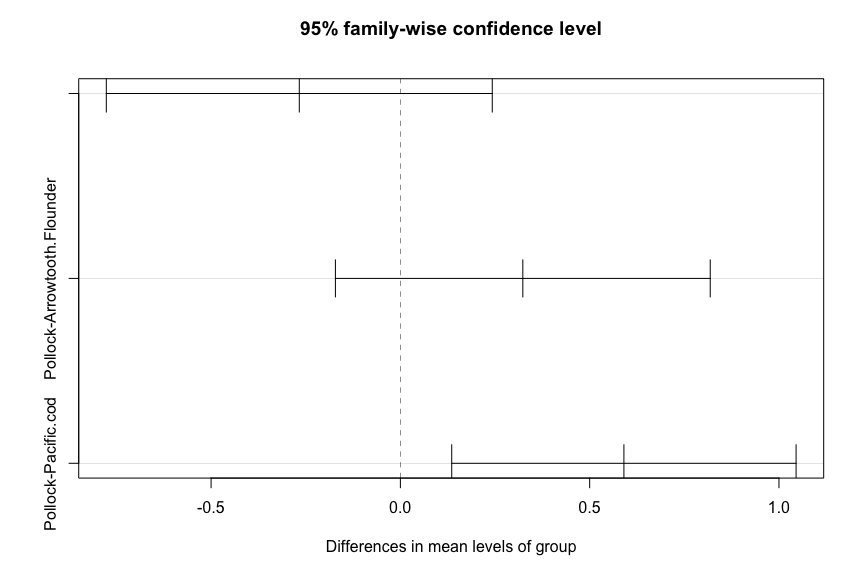

```r
# perform Tukey's posthoc test between the means
mod.HSD <- TukeyHSD(mod)

# plot the post hoc test results
par(mfrow = c(1,1))
plot(mod.HSD)
```

## Perform CAP analysis / analogue

As per the help files for `?capscale` and the related `?dbrda`, if we use Euclidean distances, as we do here, then `capscale` is identical to `rda` with the latter also being more efficient. Depending on the details of what one wants to achieve with this analysis which has its origins in PRIMER, you may want to explore more about these alternative functions.

```r
# fit rda model from the vegan package
CAP_like_analysis <- vegan::rda( Y_muscle  ~ Species,
                 data = mydata,
                 dist = "euclidean")

# try to predict a value for an "Arrowtooth.Flounder"
# for example.
predict(CAP_like_analysis,
        newdata = data.frame(Species =
                               "Arrowtooth.Flounder"))
```

```
  Muscle.d13C Muscle.d15N
1   -20.07823    14.64197
```

## Correlations

A quick plot of d13C against d15N to explore correlations in the muscle data for a question that came up in the session.

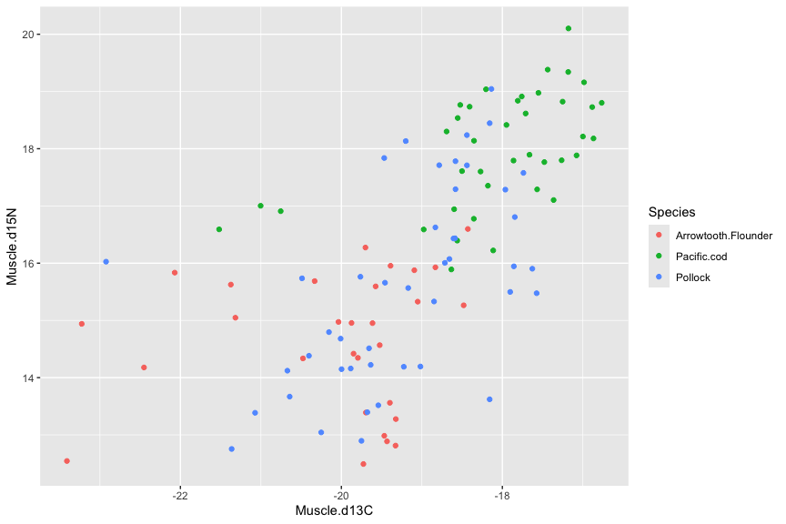

```r
ggplot(data = mydata, mapping = aes(x = Muscle.d13C, Muscle.d15N))+
  geom_point(aes(color = Species))
```